# MRR BIO Project

RIZKI Chaimae et JABILOU Hiba Binomial number:10

```r
options(warn=-1)
```

# Introduction:

Our project aims at studying which markers explain well a precise phenotype. First we will conduct an exploratory data analysis in order to gain a better understanding of our covariables and the target variable(*Alkali spreading value*), Then we’ll build multiple models in order to discover the covariables that have the most impact on the choosen phenotype. Finally, we will interpret the results and do a comparison between all the models we built based on the variables each model selected.

# Part 1: Exploratory data analysis

## Loading the data

```r
load("project_park.RData")
```

## The shape of the features matrix Xmat

```r
library(glue)
glue('The number of rows: {nrow(Xmat)}. The number of columns: {ncol(Xmat)}.')
```

```
## The number of rows: 413. The number of columns: 36901.
```

## Defining our target

Let’s first view a summary of the variables present in the phenotype dataset:

```r
summary(pheno.df)
```

```
##     HybID              NSFTVID      Flowering.time.at.Arkansas
##  Length:413         Min.   :  1.0   Min.   : 54.50
##  Class :character   1st Qu.:112.0   1st Qu.: 79.75
##  Mode  :character   Median :217.0   Median : 87.71
##                     Mean   :234.1   Mean   : 87.94
##                     3rd Qu.:322.0   3rd Qu.: 96.83
##                     Max.   :652.0   Max.   :150.50
##                                     NA's   :39
##  Flowering.time.at.Faridpur Flowering.time.at.Aberdeen
##  Min.   : 39.00             Min.   : 45.0
##  1st Qu.: 66.00             1st Qu.: 81.5
##  Median : 74.00             Median : 99.0
##  Mean   : 71.77             Mean   :107.1
##  3rd Qu.: 78.00             3rd Qu.:114.0
##  Max.   :110.00             Max.   :306.0
##  NA's   :108                NA's   :54
##  FT.ratio.of.Arkansas.Aberdeen FT.ratio.of.Faridpur.Aberdeen   Culm.habit
##  Min.   :0.3724                Min.   :0.3459                Min.   :1.000
##  1st Qu.:0.7975                1st Qu.:0.6838                1st Qu.:3.000
##  Median :0.8960                Median :0.7720                Median :4.000
##  Mean   :0.8949                Mean   :0.7711                Mean   :4.228
##  3rd Qu.:1.0195                3rd Qu.:0.8671                3rd Qu.:5.500
##  Max.   :1.7031                Max.   :1.2885                Max.   :9.000
##  NA's   :64                    NA's   :109                   NA's   :29
##  Leaf.pubescence  Flag.leaf.length Flag.leaf.width   Awn.presence
##  Min.   :0.0000   Min.   :15.42    Min.   :0.5917   Min.   :0.0000
##  1st Qu.:1.0000   1st Qu.:26.62    1st Qu.:1.0400   1st Qu.:0.0000
##  Median :1.0000   Median :30.05    Median :1.1833   Median :0.0000
##  Mean   :0.8507   Mean   :30.63    Mean   :1.2217   Mean   :0.2222
##  3rd Qu.:1.0000   3rd Qu.:34.55    3rd Qu.:1.4111   3rd Qu.:0.0000
##  Max.   :1.0000   Max.   :49.44    Max.   :1.8917   Max.   :1.0000
##  NA's   :125      NA's   :36       NA's   :36       NA's   :44
##  Panicle.number.per.plant  Plant.height    Panicle.length
##  Min.   :2.234            Min.   : 67.75   Min.   :15.63
##  1st Qu.:2.931            1st Qu.: 99.75   1st Qu.:22.24
##  Median :3.242            Median :117.50   Median :24.19
##  Mean   :3.247            Mean   :116.58   Mean   :24.37
##  3rd Qu.:3.558            3rd Qu.:131.39   3rd Qu.:26.45
##  Max.   :4.172            Max.   :194.33   Max.   :35.68
##  NA's   :41               NA's   :30       NA's   :38
```

[output cut: 49 more lines]

```
##  Min.   :2.000          Min.   : 6.500   Min.   : 53.00
##  1st Qu.:5.403          1st Qu.: 7.950   1st Qu.: 77.00
##  Median :6.083          Median : 8.450   Median : 84.50
##  Mean   :5.974          Mean   : 8.593   Mean   : 86.65
##  3rd Qu.:6.938          3rd Qu.: 9.050   3rd Qu.: 97.00
##  Max.   :7.000          Max.   :14.100   Max.   :150.50
##  NA's   :10             NA's   :20       NA's   :46
##  Year06Flowering.time.at.Arkansas
##  Min.   : 56.00
##  1st Qu.: 82.33
##  Median : 88.00
##  Mean   : 88.62
##  3rd Qu.: 95.50
##  Max.   :117.17
##  NA's   :76
```

We observed that the variable Alkali.spreading.value has the least missing values, so we decided to choose it as our target.

```r
target<-pheno.df$Alkali.spreading.value
```

## Calculating the correlation between the target and the covariables:

Our dataset contains many variables, so computing correlation matrix between the whole variables would be computationally expensive. That’s why we first viewed correlations between each variable and the target to discover the most correlated with the target. We chose a significance level 0.3 to leave only the most correlated with the target.

```r
corr_simple <- function(data=Xmat,sig=0.3){

  corr <- cor(target,data,method="kendall",use = "pairwise.complete.obs")
  corr[lower.tri(corr,diag=TRUE)] <- NA
  corr[corr == 1] <- NA
  corr <- as.data.frame(as.table(corr))
  corr <- na.omit(corr)
  corr <- subset(corr, abs(Freq) > sig)
  corr <- corr[order(-abs(corr$Freq)),]
  return (corr)
}
```

## Discovering the correation between the covariables

After discovering the variables that are the most correlated with the target, we’ll plot the correlation matrix that describes the correlation between the variables.

we will first select the 10 most correlated variables with the target.

```r
correlation_table<-corr_simple()
correlation_table[1]<-NULL
names(correlation_table)[1] <- "Feature"
names(correlation_table)[2] <- "Correlation_value"
correlation_table<-correlation_table[1:10,]
correlation_table
```

```
##         Feature Correlation_value
## 21314 id6004500        -0.4329007
## 3614  id1016702        -0.3978228
## 11933 id3006939        -0.3868313
## 27456 id8006130        -0.3866356
## 12045 id3007381        -0.3857677
## 21541 id6005779         0.3833912
## 21538 id6005758         0.3831318
## 21533 id6005732         0.3813388
## 12052 id3007397        -0.3783712
## 12058 id3007408        -0.3777081
```

The correlation table above shows that id6004500 is the variable that is the most correlated with our target, we will select the 10 most correlated variables from Xmat in order to view correlation between them.

```r
data<-Xmat[,c('id6004500','id1016702','id3006939','id8006130','id3007381','id6005779','id6005758','id6005732','id3007397','id3007408')]
```

**The correlation plot**:

```r
target<-pheno.df$Alkali.spreading.value
data<-data.frame(data)
data$Target<-target
head(data)
```

```
##   id6004500 id1016702 id3006939 id8006130 id3007381 id6005779 id6005758
## 1         0         0         0         0         0         0         0
## 3         2         2         2        NA         2         2         2
## 4         2         2         2         2         2         2         2
## 5         2         2         2         2         0         0         0
## 6         2         2        NA         2         2         0         0
## 7         2         2         2         2         0         0         0
##   id6005732 id3007397 id3007408   Target
## 1         0         0         0 6.083333
## 3         2         2         2 5.638889
## 4         2         2         2 5.527778
## 5         0         0         0 6.027778
## 6         0         2         2 5.444444
## 7         0         0         0 6.000000
```

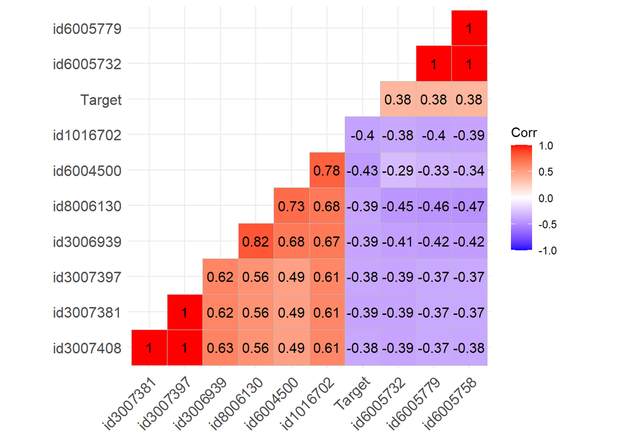

```r
library(ggplot2)
library(ggcorrplot)
ggcorrplot(cor(data,method="kendall",use = "pairwise.complete.obs"), hc.order = TRUE, type = "lower",
   lab = TRUE)
```

The correlation plot above shows that many of our covariables are highly correlated. For example, id8006130 is highly correlated with id3006939 since the correlation value surpasses 0.7.

## Exploring our covariables and our target

### Distribution of target variable

Our target variable is continuous we will plot a box plot of the target in order to understand better its distribution, and also check if there are any outliers.

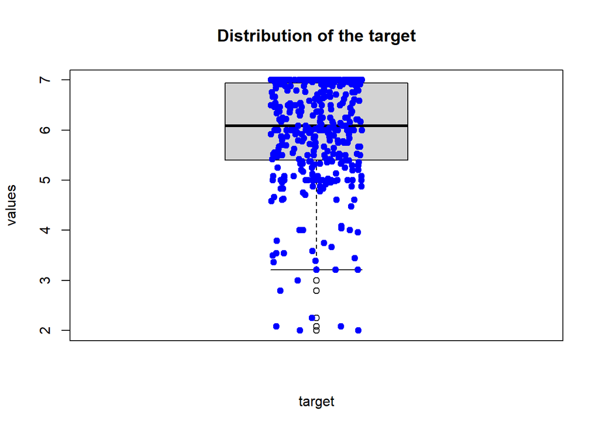

```r
boxplot(target)
stripchart(target, vertical=TRUE,method = "jitter", pch = 19, add = TRUE, col = "blue")
title(main = "Distribution of the target", xlab = "target", ylab = "values")
```

### Summary of the 10 most correlated variables with the target.

```r
names<-c('id6004500','id1016702','id3006939','id8006130','id3007381','id6005779','id6005758','id6005732','id3007397','id3007408')
data[,names]<-lapply(data[,names],factor)
summary(data)
```

```
##  id6004500  id1016702  id3006939  id8006130  id3007381  id6005779  id6005758
##  0   :174   0   :136   0   :107   0   :122   0   :215   0   :279   0   :277
##  2   :222   2   :154   2   :215   2   :204   2   :192   2   :121   2   :126
##  NA's: 17   NA's:123   NA's: 91   NA's: 87   NA's:  6   NA's: 13   NA's: 10
##
##
##
##
##  id6005732  id3007397 id3007408      Target
##  0   :254   0:216     0   :212   Min.   :2.000
##  2   :128   1:  2     2   :193   1st Qu.:5.403
##  NA's: 31   2:195     NA's:  8   Median :6.083
##                                  Mean   :5.974
##                                  3rd Qu.:6.938
##                                  Max.   :7.000
##                                  NA's   :10
```

According to the summary of our variables, there are many missing values. Since our features are categorical, we will impute the missing values with the mode. And for the target variable, we’ll remove the missing values since all the values are needed for the target variable in order to build the model and test it.

# Part 2: Missing values imputation and data partitionning

## Missing value imputation for the covariables

```r
library(missMethods)
data<-impute_mode(Xmat, type = "columnwise", convert_tibble = TRUE) #imputing with the use of mode
```

## Missing values removal for the target

**Concatenating the target with the dataframe**

```r
target<-pheno.df$Alkali.spreading.value
data=data.frame(data)
data$Target<-target
```

```r
library(tidyverse)
data=data[!is.na(data$Target),]
dim(data)
```

```
## [1]   403 36902
```

## Data Partionning into train and test

In order to build our model and evaluate its performance, it is mandatory to split the data into train and test. We chose a ratio of 0.2 for the test set.

```r
set.seed(4)
index = sample(1:nrow(data), 0.8*nrow(data))

train = data[index,] # Create the training data
test = data[-index,] # Create the test data

dim(train)
```

```
## [1]   322 36902
```

```r
dim(test)
```

```
## [1]    81 36902
```

# Building the models:

Since our target is continuous, we will build a linear regression model to explain the target with the help of the covariables. Our exploratory data analysis showed us previously that the number of covariables is much larger than the number of covariables. That’s why we can’t apply the standard linear model, and we will resort to penalized regression methods, forward linear regression and principal component regression.

## Penalized regression methods:

We are going to use lasso regression and ELastic Net, since they also perform variable selection by allowing coefficients to shrink to 0

### Lasso Regression:

In Lasso Regression, the OLS loss function is augmented and aletered in such a way that we not only minimize the sum of squared residuals but also penalize the size of parameter estimates, in order to shrink the least significant coefficients towards zero. **The lasso regression formula**: Let n be the number of observations, p the number of variables and x_i the i’th features vector and y_i the i’th target value. lambda is called the penalty term. Setting λ to 0 is the same as using the OLS, and as lambda increases, the penalty term increases and the coefficients shrink towards 0. The optimal value of lambda is found thanks to cross validation, we pick the lambda that minimizes the mean squared error.

$$L_{lasso}(\beta)=\sum_{i=1}^{n}(y_i-x_i\beta)^2+\lambda\sum_{i=1}^{p}|\beta_i|$$

**Finding the optimal lambda**: We perform cross validation on our train set, the number of folds is by default 10.

```r
X <- as.matrix(select(train,-Target))
#  vector of target value
Y<- train$Target
library(glmnet)
set.seed(4)
cross_validation_lambda <- cv.glmnet(X, Y,alpha=1)
```

We’ll plot the mean squared mean error with respect to lambda in order to gain an understanding about the lambda value that minimizes the error.

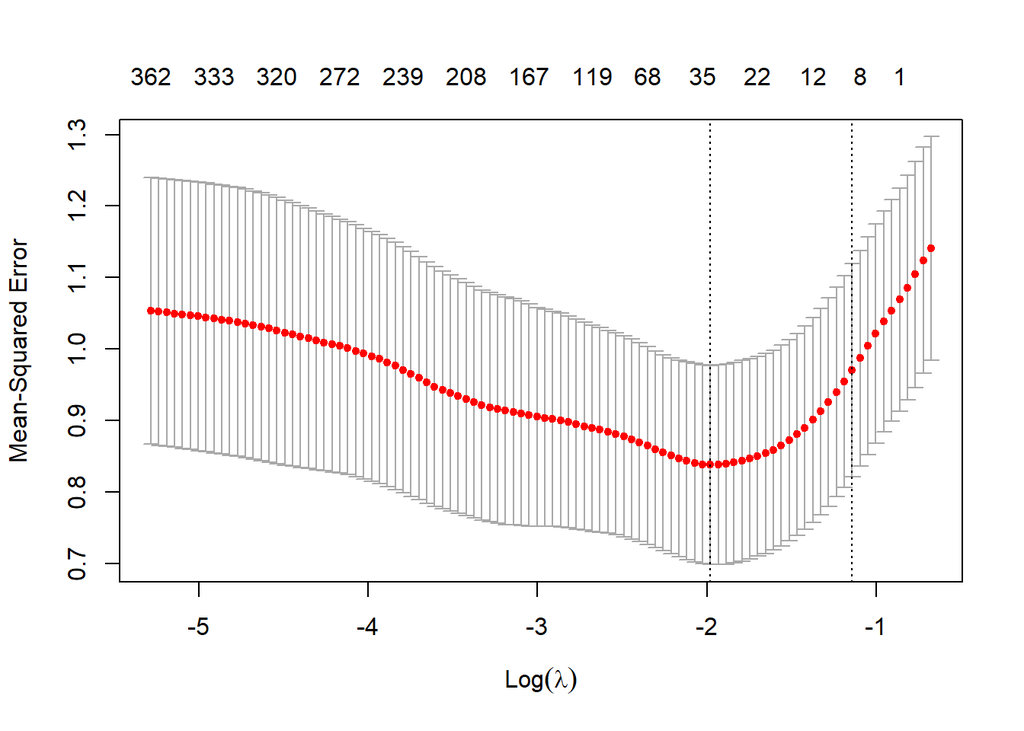

```r
plot(cross_validation_lambda)
```

Now, we’ll retrieve the lambda value that minimizes the error

```r
optimal_lambda_lasso<-cross_validation_lambda$lambda.min
library(glue)
glue('The optimal lambda value: {optimal_lambda_lasso}')
```

```
## The optimal lambda value: 0.138156329371319
```

```r
library(glmnet)
model_lasso<-glmnet(X, Y, alpha = 1 , lambda = optimal_lambda_lasso)
```

```r
coef_dataframe_lasso<-coef(model_lasso)
coef_dataframe_lasso=data.frame(coef_dataframe_lasso[coef_dataframe_lasso[,1]!=0,])
names(coef_dataframe_lasso)[1] <- "Coefficient value"
significant_coef_lasso=c()
significant_coef_lasso<-append(significant_coef_lasso,row.names(coef_dataframe_lasso))
significant_coef_lasso<- significant_coef_lasso[! significant_coef_lasso %in% c("(Intercept)")]
library(glue)
glue('The number of coefficients that the lasso regression has not nullified : {length(significant_coef_lasso)}')
```

```
## The number of coefficients that the lasso regression has not nullified : 32
```

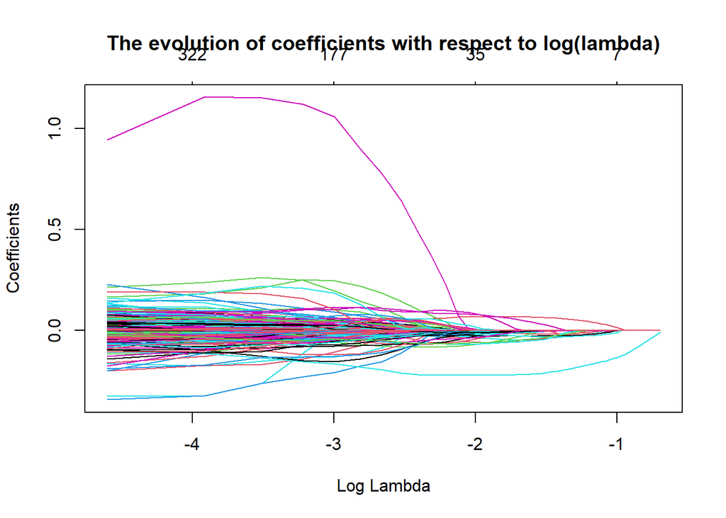

```r
grid=seq(0,0.5, by = 0.01)
model<-glmnet(X,Y,lambda=grid,alpha=1)
plot(model, xvar = "lambda",main="The evolution of coefficients with respect to log(lambda)")
```

As it’s shown in the picture above, as lambda increases, the less coefficicient estimates become close to 0. This helps our model to select only the significant variables.

### Elastic Net regression:

Elastic Net is a penalized regression method that allows a balance of both penalties(lasso and ridge regression). It relies on the hyper parameter alpha that balances the two penalization approaches : Set to 0 for ridge and 1 for lasso.

**Elastic Net formula**: Let n be the total number of observations, p the number of covariables. y_i denotes the ith target value, and x_i denotes the ith observation vector. lambda is the penalty term, and lambda is the mixing parameter between ridge and lasso if it’s 0, than the formula becomes the formula of ridge regression. if it’s set to 1, than it’s the formula of lasso regression. In order to find the optimal values for the hyperparameters lambda and alpha we have to apply cross validation on the train set.
$$L_{enet}(\beta)=\frac{\sum_{i=1}^{n}(y_i-x_i\beta)^2}{2n}+\lambda(\alpha\sum_{i=1}^{p}|\beta_i| +\frac{1-\alpha}{2}\sum_{i=1}^{p}(\beta_i)^2)$$
**Hyperparameter tuning for alpha**: To find the optimal value of alpha, we perform cross validation consisting of 10 folds on our training set, we test different values of alpha ranging from 0.1 to 0.9. The best alpha is the one that minimizes the mean squared error.

```r
alpha <- seq(0.1, 0.9, 0.1) #alpha is iterated from 0.1 to 0.9
best <- list(a=NULL, mse=NULL)

for (i in 1:length(alpha))
{
   cvg <- cv.glmnet(X, Y, alpha = alpha[i])
   best$a <- c(best$a, alpha[i])
   best$mse <- c(best$mse, min(cvg$cvm))
}
index <- which(best$mse==min(best$mse))
best_alpha <- best$a[index]
best_mse <- best$mse[index]
cat("alpha:", best_alpha, " mse:", best_mse)
```

```
## alpha: 0.4  mse: 0.8191842
```

**Hyperparameter tuning for lambda**: we apply cross-validation again with the best alpha to get the lambda (shrinkage level)

```r
elastic_cv <- cv.glmnet(X,Y, alpha = best_alpha)
best_lambda <- elastic_cv$lambda.min
cat("The best value for lambda: ",best_lambda)
```

```
## The best value for lambda:  0.3453908
```

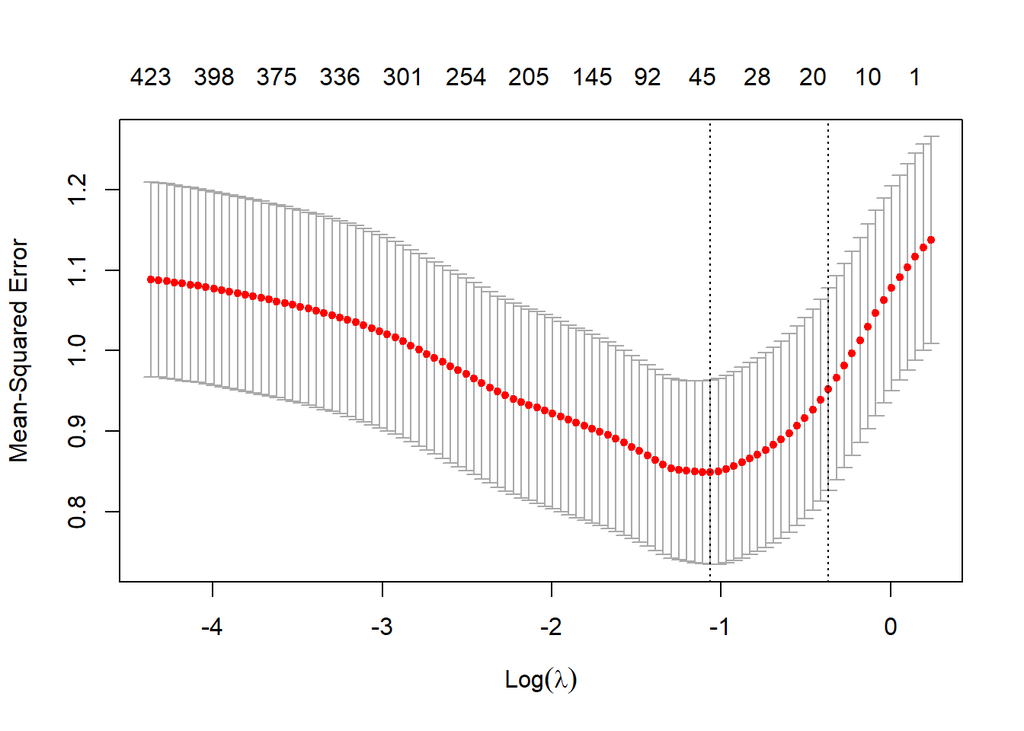

```r
plot(elastic_cv, xvar = "lambda",label=TRUE)
```

As it’s shown in the plot above, lambda is chosen as the optimal value that minimizes the mean squared error.

**Building the elastic net model**: now we will build the elastic net model with the optimal hyperparameters.

```r
elastic_mod <- glmnet(X, Y, alpha = best_alpha, lambda = best_lambda)
```

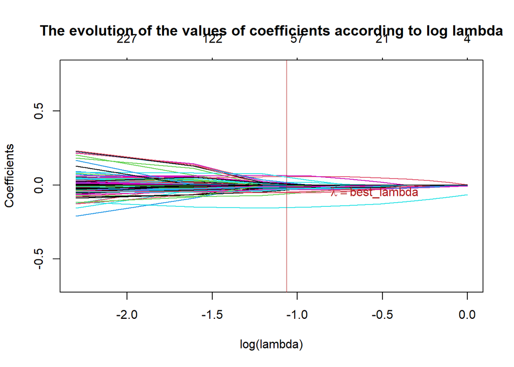

```r
grid <- seq(0,1 , by = 0.1)
elastic<- glmnet(X, Y, alpha = best_alpha, lambda = grid)

# Plot the coefficients against the (natural) LOG lambda sequence!
# see ?plot.glmnet
plot(elastic, xvar = "lambda", xlab = "log(lambda)",main="The evolution of the values of coefficients according to log lambda")
# add a vertical line at lambda = 2
text(log(best_lambda), -0.05, labels = expression(lambda == best_lambda),
     adj = -0.5, col = "firebrick")
abline(v = log(best_lambda), col = "firebrick", lwd = best_lambda)
```

As it’s shown in the picture above, after the vertical line passing through the optimal lambda value, only significant coefficients are kept in the model, the rest is nullified.

```r
coef_dataframe_elastic<-coef(elastic_mod)
coef_dataframe_elastic=data.frame(coef_dataframe_elastic[coef_dataframe_elastic[,1]!=0,])
names(coef_dataframe_elastic)[1] <- "Coefficient value"
significant_coef_elastic=c()
significant_coef_elastic<-append(significant_coef_elastic,row.names(coef_dataframe_elastic))
significant_coef_elastic<- significant_coef_elastic[! significant_coef_elastic %in% c("(Intercept)")]
library(glue)
glue('The number of coefficients that the elastic net regression has not nullified: {length(significant_coef_elastic)}')
```

```
## The number of coefficients that the elastic net regression has not nullified: 39
```

## Stepwise regression model:

Another way to perform model selection is to use forward regression method. To apply this method on our dataset we will use the package bigstep which allows us to deal with high-dimensional data. First, since we are dealing with many predictors, we can start by removing those that are not strongly relate to the target. We perform the pearson correlation test and we calculate p-value for each covariable. We define a significance level of 0.15, so that variables with p-values higher than 0.15 will be removed. Next, we perform stepwise regression using the mbic which is modified version of the BIC that introduces a much heavier penalty, so that it helps us end up with a parsimonious model that is based on the most significant predictors.

```r
library(bigstep)
data_selection<-prepare_data(Y,X)
data_selection<-reduce_matrix(data_selection,minpv=0.15)
```

```
## Performing single tests...
```

```
## Number of variables reduced to 15634.
```

```r
results<-stepwise(data_selection,crit=mbic)
```

```
## Starting stepwise, 0 variables, crit = 40.92, MSE = 1.136.
```

```
## Variable id6004500 added with crit = -18.14, MSE = 0.877.
```

```
## Variable id5004697 added with crit = -44.2, MSE = 0.751.
```

```
## Done.
```

```r
significant_coef_stepwise=c()
significant_coef_stepwise<-append(significant_coef_stepwise,rownames(data.frame(summary(results)$coefficients)))
significant_coef_stepwise<- significant_coef_stepwise[! significant_coef_stepwise %in% c("(Intercept)")]
summary(results)
```

```
##
## Call:
## lm(formula = y ~ ., data = as.data.frame(Xm[, -1]))
##
## Residuals:
##     Min      1Q  Median      3Q     Max
## -3.7172 -0.3754  0.1438  0.3353  2.0148
##
## Coefficients:
##             Estimate Std. Error t value Pr(>|t|)
## (Intercept)  6.75084    0.07956  84.849  < 2e-16 ***
## id6004500   -0.49098    0.04922  -9.976  < 2e-16 ***
## id5004697   -0.39182    0.05347  -7.328 1.93e-12 ***
## ---
## Signif. codes:  0 '***' 0.001 '**' 0.01 '*' 0.05 '.' 0.1 ' ' 1
##
## Residual standard error: 0.8706 on 319 degrees of freedom
## Multiple R-squared:  0.3388, Adjusted R-squared:  0.3346
## F-statistic: 81.71 on 2 and 319 DF,  p-value: < 2.2e-16
```

## Best subset selection algorithm

We run the best subset selection algorithm using the BeSS package, which is recommended for high dimensional data, and it suggests optimized algorithms such as GPDAS to determine the optimal subset size, and builds models with the optimal subset size and selects the one that minimizes the specified criterion (BIC or AIC). Usually the best subset algorithm is computationally expensive but the BeSS runs the algorithm fast since the algorithms are built in C++.

```r
library("BeSS")
fit.bestsubset <- bess(as.matrix(X), Y,family="gaussian",method = "sequential")
significant_coef_bestsubset=c()
significant_coef_bestsubset<-append(significant_coef_bestsubset,rownames(data.frame(summary(fit.bestsubset$bestmodel)$coefficients)))
significant_coef_bestsubset<- significant_coef_bestsubset[! significant_coef_bestsubset %in% c("(Intercept)")]
summary(fit.bestsubset$bestmodel)
```

```
##
## Call:
## lm(formula = ys ~ xbest, weights = weights)
##
## Residuals:
##      Min       1Q   Median       3Q      Max
## -0.96950 -0.18758  0.00691  0.18693  0.88451
##
## Coefficients:
##                 Estimate Std. Error t value Pr(>|t|)
## (Intercept)      0.71103    0.72795   0.977 0.329580
## xbestid1004156   0.57901    0.04448  13.016  < 2e-16 ***
## xbestdd1000366  -0.14378    0.03213  -4.475 1.13e-05 ***
## xbestdd1001212  -0.56320    0.06854  -8.216 9.35e-15 ***
## xbestid1017332   0.19687    0.08122   2.424 0.016019 *
## xbestid1024912   0.10657    0.02926   3.642 0.000325 ***
## xbestdd1001905   0.14848    0.04743   3.131 0.001940 **
## xbestid1027710  -0.21084    0.06937  -3.040 0.002606 **
## xbestdd1001995   0.33304    0.06681   4.985 1.12e-06 ***
## xbestid2001829   0.18841    0.04233   4.451 1.26e-05 ***
## xbestid2002589  -0.13473    0.03682  -3.659 0.000306 ***
## xbestid2004668   0.24452    0.02665   9.174  < 2e-16 ***
## xbestid2005022  -0.27995    0.07462  -3.752 0.000216 ***
## xbestid2009411   0.24065    0.03729   6.453 5.20e-10 ***
## xbestid2016537  -0.39316    0.03724 -10.559  < 2e-16 ***
## xbestid3007943   0.34174    0.07233   4.725 3.74e-06 ***
## xbestid3008091  -0.22970    0.02901  -7.919 6.60e-14 ***
## xbestid3009825  -0.52888    0.08884  -5.954 8.30e-09 ***
## xbestwd4000011  -0.87653    0.13487  -6.499 3.99e-10 ***
## xbestid4005094  -0.09636    0.02465  -3.909 0.000118 ***
## xbestid4005926  -0.36701    0.08706  -4.216 3.42e-05 ***
## xbestid4010619  -0.14111    0.03704  -3.809 0.000173 ***
## xbestwd4003191   0.32769    0.10524   3.114 0.002050 **
## xbestid5001311   0.32401    0.03210  10.094  < 2e-16 ***
## xbestid5004697  -0.39648    0.03541 -11.196  < 2e-16 ***
## xbestid5006210  -0.20075    0.02529  -7.940 5.78e-14 ***
## xbestid5006463  -0.33952    0.05578  -6.087 4.02e-09 ***
## xbestid5013215   0.46570    0.06630   7.024 1.81e-11 ***
## xbestid6000172   0.10445    0.03260   3.204 0.001521 **
## xbestid6001941  -0.22512    0.03962  -5.682 3.49e-08 ***
```

[output cut: 18 more lines]

```
## xbestdd11000951 -0.17833    0.03716  -4.799 2.66e-06 ***
## xbestid11009957  0.24970    0.02791   8.947  < 2e-16 ***
## xbestid11010404  0.26315    0.03507   7.503 9.46e-13 ***
## xbestud12000591 -0.39753    0.07686  -5.172 4.57e-07 ***
## xbestid12005174 -0.21457    0.03132  -6.851 5.11e-11 ***
## xbestid12006742  0.40653    0.05346   7.604 5.00e-13 ***
## xbestid12007462  0.11279    0.03965   2.844 0.004796 **
## xbestid12009884 -0.38801    0.05202  -7.459 1.25e-12 ***
## xbestid12010043  0.76596    0.09969   7.683 3.02e-13 ***
## ---
## Signif. codes:  0 '***' 0.001 '**' 0.01 '*' 0.05 '.' 0.1 ' ' 1
##
## Residual standard error: 0.3446 on 265 degrees of freedom
## Multiple R-squared:  0.914,  Adjusted R-squared:  0.8958
## F-statistic: 50.26 on 56 and 265 DF,  p-value: < 2.2e-16
```

```r
significant_coef_bestsubset
```

```
##  [1] "xbestid1004156"  "xbestdd1000366"  "xbestdd1001212"  "xbestid1017332"
##  [5] "xbestid1024912"  "xbestdd1001905"  "xbestid1027710"  "xbestdd1001995"
##  [9] "xbestid2001829"  "xbestid2002589"  "xbestid2004668"  "xbestid2005022"
## [13] "xbestid2009411"  "xbestid2016537"  "xbestid3007943"  "xbestid3008091"
## [17] "xbestid3009825"  "xbestwd4000011"  "xbestid4005094"  "xbestid4005926"
## [21] "xbestid4010619"  "xbestwd4003191"  "xbestid5001311"  "xbestid5004697"
## [25] "xbestid5006210"  "xbestid5006463"  "xbestid5013215"  "xbestid6000172"
## [29] "xbestid6001941"  "xbestid6004500"  "xbestud6000367"  "xbestid6006361"
## [33] "xbestid6010179"  "xbestid6011854"  "xbestid6012727"  "xbestid7003044"
## [37] "xbestid7003114"  "xbestid8002877"  "xbestid8003299"  "xbestid8004988"
## [41] "xbestid8005299"  "xbestid8005807"  "xbestid9002166"  "xbestid10000708"
## [45] "xbestid10001512" "xbestwd10001632" "xbestdd11000245" "xbestdd11000951"
## [49] "xbestid11009957" "xbestid11010404" "xbestud12000591" "xbestid12005174"
## [53] "xbestid12006742" "xbestid12007462" "xbestid12009884" "xbestid12010043"
```

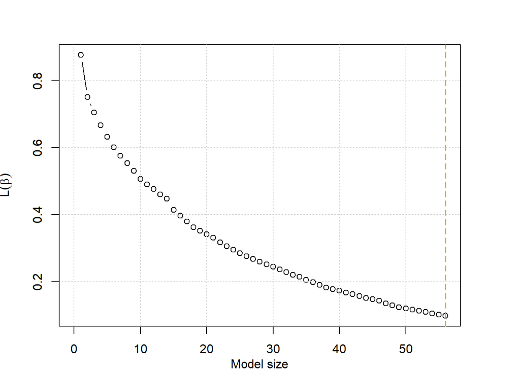

```r
plot(fit.bestsubset)
```

In the plot above, the yellow dashed line represents the optimal number of variables that minimize the BIC criterion. We observe that 56 is the optimal number of variables.

# Evaluating and comparing the models:

This part is dedicated to the comparison of the results yielded by each model, from a technical point of view (comparing metrics such as RMSE and R-squared) and also, form to compare the variable choosen as most significant by each model.

## Comparison of the variables selected by each model

```r
#Models<-c("Lasso","Elastic Net","Stepwise")
#Variables<-list(significant_coef_lasso,significant_coef_elastic,significant_coef_stepwise)
#models=data.frame(cbind(Models, Variables))
#models
cat("Variables selected by Lasso regression: ",significant_coef_lasso,"\n\n")
```

```
## Variables selected by Lasso regression:  dd1001228 ud3000632 id3007076 id3007397 id3008091 id3010833 id3010837 id4000311 id4001100 id4001111 id4001678 id4001879 id4002775 ud5000604 id6004146 id6004240 id6004500 id6004973 id6005000 id6005779 id6006125 id6012727 id7003038 id7003044 id9001769 id1100…
```

```r
cat("Variable selected by Elastic Net: ", significant_coef_elastic,"\n\n")
```

```
## Variable selected by Elastic Net:  dd1001228 ud3000632 id3007076 id3007381 id3007397 id3007406 id3008091 id3008160 id3010833 id3010834 id3010837 id3011021 id4000311 id4001100 id4001111 id4001678 id4001879 id4002775 id5003117 id5004697 ud5000604 id6004146 id6004240 id6004500 id6004973 id6005000 id…
```

```r
cat("Variables selected by Stepwise: ",significant_coef_stepwise,"\n\n")
```

```
## Variables selected by Stepwise:  id6004500 id5004697
```

```r
print("Variables selected by Best subset method")
```

```
## [1] "Variables selected by Best subset method"
```

```r
print(significant_coef_bestsubset)
```

```
##  [1] "xbestid1004156"  "xbestdd1000366"  "xbestdd1001212"  "xbestid1017332"
##  [5] "xbestid1024912"  "xbestdd1001905"  "xbestid1027710"  "xbestdd1001995"
##  [9] "xbestid2001829"  "xbestid2002589"  "xbestid2004668"  "xbestid2005022"
## [13] "xbestid2009411"  "xbestid2016537"  "xbestid3007943"  "xbestid3008091"
## [17] "xbestid3009825"  "xbestwd4000011"  "xbestid4005094"  "xbestid4005926"
## [21] "xbestid4010619"  "xbestwd4003191"  "xbestid5001311"  "xbestid5004697"
## [25] "xbestid5006210"  "xbestid5006463"  "xbestid5013215"  "xbestid6000172"
## [29] "xbestid6001941"  "xbestid6004500"  "xbestud6000367"  "xbestid6006361"
## [33] "xbestid6010179"  "xbestid6011854"  "xbestid6012727"  "xbestid7003044"
## [37] "xbestid7003114"  "xbestid8002877"  "xbestid8003299"  "xbestid8004988"
## [41] "xbestid8005299"  "xbestid8005807"  "xbestid9002166"  "xbestid10000708"
## [45] "xbestid10001512" "xbestwd10001632" "xbestdd11000245" "xbestdd11000951"
## [49] "xbestid11009957" "xbestid11010404" "xbestud12000591" "xbestid12005174"
## [53] "xbestid12006742" "xbestid12007462" "xbestid12009884" "xbestid12010043"
```

The results above show that only one variable is selected in common between our three models, which means it is the variable id6004500 that helps explain well our target, which is not surprising, because according to the correlation matrix we computed before, it is the most correlated variable with the target. Concerning lasso and Elastic Net regression, most selected predictors are common between them.

### PCA:

Another way to deal with high dimensional data is to use PCA to reduce the dimensions while retaining as much variation between the observations as possible. Principal component analysis is used to extract the important information from a multivariate data table and to express this information as a set of few new variables called principal components using the Correlation or variance-covariance matrix.

**How it works:** PCA first transforms the original variables to principal directions which we call the principal components (PCs). The principal components are a linear combinations set of the original variables, are uncorrelated, and are ordered/ranked. PCA then deems that the PCs with the largest variances are the most important (measured by eigenvalues).

```r
library("FactoMineR")
library("factoextra")
library(tidyverse)
```

```r
features<-subset(select(data,-Target))
res.pca<-PCA(features, graph = FALSE)
```

**get eigen values :**

```r
library("factoextra")
eig.val <- get_eigenvalue(res.pca)
eig.val
```

```
##           eigenvalue variance.percent cumulative.variance.percent
## Dim.1   11837.195053     32.079019497                    32.07902
## Dim.2    3532.964078      9.574398582                    41.65342
## Dim.3    2071.248663      5.613122531                    47.26654
## Dim.4     839.154160      2.274123433                    49.54066
## Dim.5     818.000000      2.216795265                    51.75746
## Dim.6     604.901804      1.639295177                    53.39675
## Dim.7     499.101854      1.352575339                    54.74933
## Dim.8     459.892846      1.246318194                    55.99565
## Dim.9     369.131476      1.000353187                    56.99600
## Dim.10    296.718825      0.804113552                    57.80011
## Dim.11    291.311278      0.789458999                    58.58957
## Dim.12    271.775242      0.736515979                    59.32609
## Dim.13    263.277227      0.713486200                    60.03958
## Dim.14    224.621746      0.608729123                    60.64831
## Dim.15    221.179525      0.599400642                    61.24771
## Dim.16    201.750136      0.546746633                    61.79445
## Dim.17    196.884650      0.533561075                    62.32801
## Dim.18    190.627496      0.516604072                    62.84462
## Dim.19    176.061780      0.477130709                    63.32175
## Dim.20    168.922469      0.457783045                    63.77953
## Dim.21    163.184241      0.442232337                    64.22176
## Dim.22    161.643206      0.438056105                    64.65982
## Dim.23    149.898693      0.406228256                    65.06605
## Dim.24    146.591631      0.397266055                    65.46331
## Dim.25    140.984889      0.382071680                    65.84539
## Dim.26    138.128317      0.374330317                    66.21972
## Dim.27    135.409592      0.366962521                    66.58668
## Dim.28    129.946991      0.352158770                    66.93884
## Dim.29    127.529263      0.345606682                    67.28444
## Dim.30    124.620422      0.337723669                    67.62217
## Dim.31    123.028426      0.333409329                    67.95558
## Dim.32    120.553138      0.326701253                    68.28228
## Dim.33    118.836705      0.322049689                    68.60433
## Dim.34    118.583843      0.321364428                    68.92569
## Dim.35    117.497303      0.318419883                    69.24411
## Dim.36    111.945000      0.303373040                    69.54749
## Dim.37    109.472034      0.296671256                    69.84416
## Dim.38    107.488502      0.291295848                    70.13545
## Dim.39    106.683285      0.289113694                    70.42457
```

[output cut: 348 more lines]

```
## Dim.388     3.066494      0.008310257                    99.92939
## Dim.389     2.902568      0.007866013                    99.93725
## Dim.390     2.655846      0.007197393                    99.94445
## Dim.391     2.530947      0.006858914                    99.95131
## Dim.392     2.393063      0.006485247                    99.95780
## Dim.393     2.049694      0.005554709                    99.96335
## Dim.394     1.930178      0.005230820                    99.96858
## Dim.395     1.916742      0.005194406                    99.97377
## Dim.396     1.752939      0.004750497                    99.97853
## Dim.397     1.657457      0.004491740                    99.98302
## Dim.398     1.534276      0.004157918                    99.98718
## Dim.399     1.338007      0.003626025                    99.99080
## Dim.400     1.212742      0.003286554                    99.99409
## Dim.401     1.118197      0.003030335                    99.99712
## Dim.402     1.063438      0.002881936                   100.00000
```

“get_eigenvalue” returns the eigenvalues of each principal components. Eigenvalues measure the amount of variation from each PC. For example, the first eigenvalue explains about 32.07% of the variation.

We observe from first glance from the eigen values that the first dimension is the one retaining the most information with 32.07% of the variation while the second has an eigen value of 9.57% and the values keep getting lower until they are of no significance.

**plot contributing variables and color them according to their contribution**

The contribution of a variable (var) to a given principal component is (in percentage) : $(var.cos2 * 100) / (total cos2 of the component). $

cos2 = represents the quality of representation for variables on the factor map. It’s calculated as the squared coordinates: var.cos2 = var.coord * var.coord.

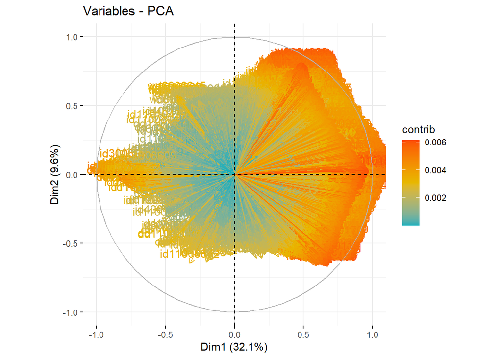

```r
fviz_pca_var(res.pca, col.var = "contrib",top=10,
             gradient.cols = c("#00AFBB", "#E7B800", "#FC4E07")
             )
```

Normally, this factor map is very useful for detecting the variables who contributed the most graphically but since the dataset contains many variables it is impossible to read the map.

#### Getting the Contributions of the original variables on dimensions

To select variables, we thought to observe their contributions on the new dimensions, thus we sorted the dataframe that gives the contribution information by descending order of contribution to DIM.1 and then to Dim.2. we picked the top 15 of each thus we selected the variables that have contributed the most in these dimensions since the first two PCs are the ones who contributes greatly to the variation and mainly the first one. **The contribution of a variable** (var) to a given principal component is (in percentage) : (var.cos2 * 100) / (total cos2 of the component).

**Ordeing by Dim.1**

```r
var <- get_pca_var(res.pca)
var
```

```
## Principal Component Analysis Results for variables
##  ===================================================
##   Name       Description
## 1 "$coord"   "Coordinates for the variables"
## 2 "$cor"     "Correlations between variables and dimensions"
## 3 "$cos2"    "Cos2 for the variables"
## 4 "$contrib" "contributions of the variables"
```

```r
head(var$contrib)
```

```
##                 Dim.1        Dim.2        Dim.3        Dim.4        Dim.5
## id1000001 0.003381103 4.262301e-03 8.050556e-05 0.0022161932 3.108872e-24
## id1000003 0.003355135 4.297916e-03 8.566802e-05 0.0029588771 3.567067e-26
## id1000005 0.001510979 1.419037e-02 1.664480e-06 0.0081059819 3.782296e-28
## id1000007 0.001177029 1.910399e-03 1.812910e-04 0.0004609466 1.533276e-27
## id1000008 0.003262215 4.241425e-03 9.074566e-05 0.0030567031 4.405403e-30
## id1000011 0.000400522 8.679496e-05 6.008717e-04 0.0006501405 2.732393e-27
```

```r
contrib=data.frame(var$contrib)
contribordered=contrib[order(contrib$Dim.1,decreasing = TRUE),c(1,2)] #ordering by descent the contribution of the original variables on dimensions
variables1=head(contribordered,15)
variables1
```

```
##                 Dim.1        Dim.2
## ud9001405 0.007996759 1.357289e-05
## id9007746 0.007982368 1.567833e-05
## id9004988 0.007966984 1.264214e-05
## id9005073 0.007966984 1.264214e-05
## id9005141 0.007966984 1.264214e-05
## id9007784 0.007956711 1.989725e-05
## id9007779 0.007953440 5.010448e-06
## id9007780 0.007953440 5.010448e-06
## ud9001410 0.007953440 5.010448e-06
## id5008733 0.007948879 1.197512e-05
## id5008768 0.007948879 1.197512e-05
## id5008660 0.007948174 1.141305e-05
## id5008667 0.007948174 1.141305e-05
## id5008677 0.007948174 1.141305e-05
## id9005523 0.007941033 7.333966e-06
```

```r
variables1[,0]
```

```
## tableau de données (data frame) avec 0 colonnes et 15 lignes
```

Thus if we search for the top 15 variables that contributed the most in **Dim1** , we have : ud9001405, id9007746, id9004988, id9005073, id9005141, id9007784, id9007779, id9007780, ud9001410, id5008733. We assume that these variables are the most significant since they contribute to Dim1 which is gives the most explanation.

**Ordeing by Dim.2**

```r
contribordered2=contrib[order(contrib$Dim.2,decreasing = TRUE),c(1,2)] #ordering by descent the contribution of the original variables on dimensions
variables2=head(contribordered2,15)
variables2
```

```
##                  Dim.1      Dim.2
## id6004033  0.002000991 0.01883651
## id5013450  0.002163255 0.01863852
## id5013620  0.002163255 0.01863852
## id6004020  0.001961296 0.01849504
## id9005245  0.002033926 0.01841269
## id3015513  0.002130256 0.01828857
## id3015584  0.002130256 0.01828857
## id12008932 0.001939820 0.01826821
## id3014874  0.002173639 0.01823963
## id6013038  0.002047864 0.01815327
## id4000080  0.002019298 0.01810841
## wd3002212  0.002142519 0.01805444
## id12008289 0.001988619 0.01803500
## id6012385  0.002239776 0.01795921
## ud5001081  0.002009580 0.01795617
```

```r
variables2[,0]
```

```
## tableau de données (data frame) avec 0 colonnes et 15 lignes
```

Thus if we search for the top 15 variables that contributed the most in **Dim2** :, we have : id6004033, id5013450, id5013620, id6004020, id9005245, id3015513, id3015584, id12008932, id3014874, id6013038

**draw a bar plot of variable contributions :**

The top 30 variables contriubution to Dim.1

The red dashed line on the graph above indicates the expected average contribution.

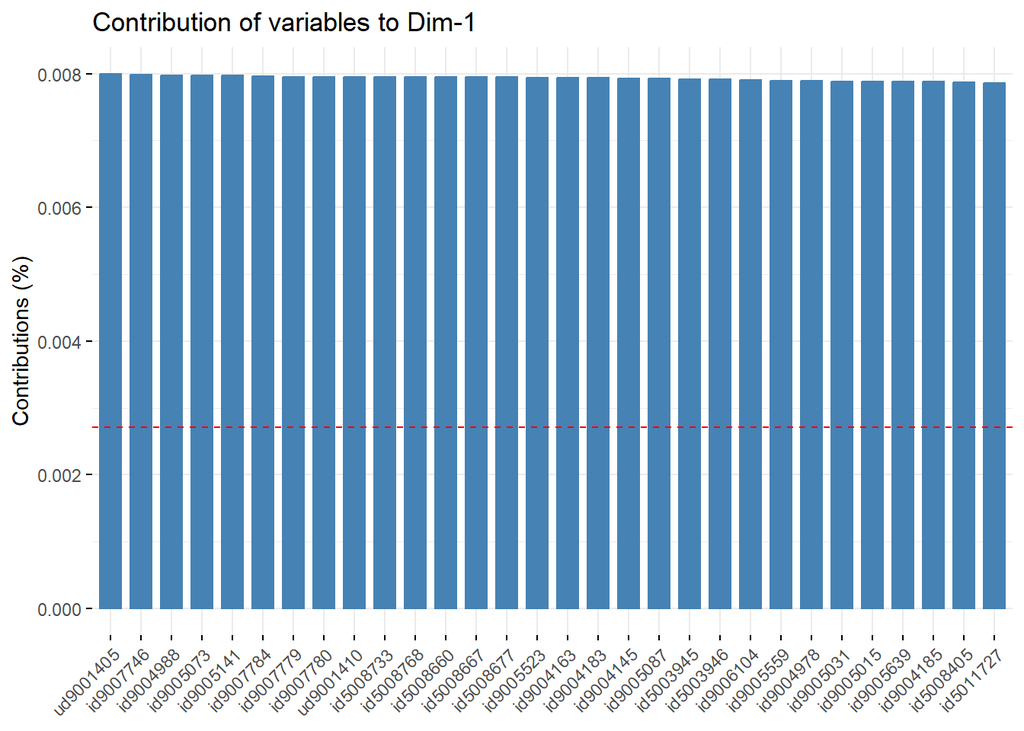

```r
# Contributions of variables to PC1
fviz_contrib(res.pca, choice = "var", axes = 1, top = 30)
```

The top 30 variables contriubution to Dim.2

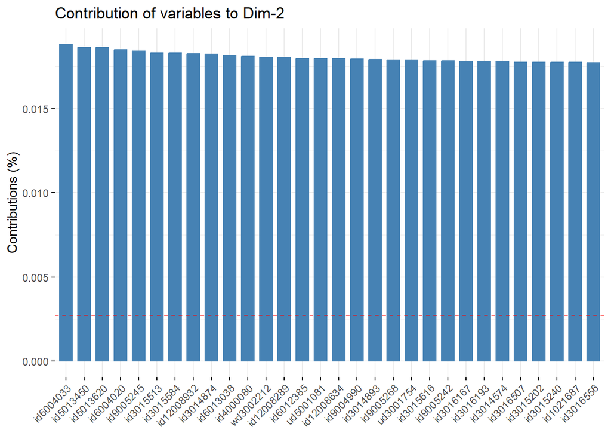

```r
# Contributions of variables to PC2
fviz_contrib(res.pca, choice = "var", axes = 2, top = 30)
```

**plot individuals and color them according to their quality on the factor map**

cos2 = represents the quality of representation for variables on the factor map. It’s calculated as the squared coordinates: var.cos2 = var.coord * var.coord.

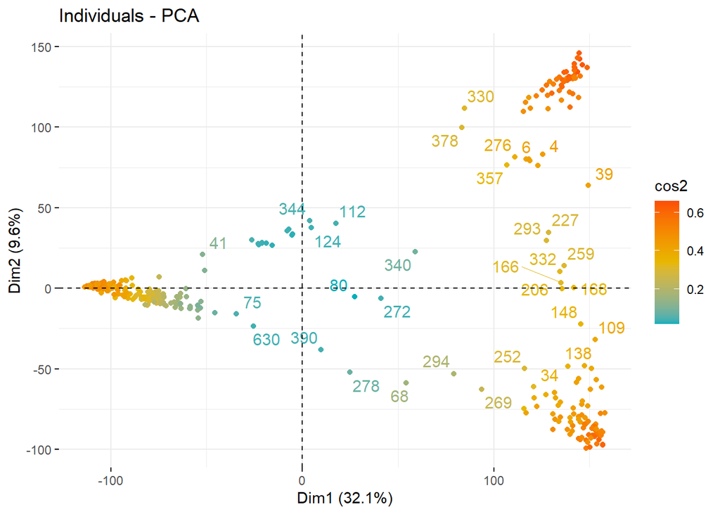

```r
fviz_pca_ind(res.pca, col.ind = "cos2",
             gradient.cols = c("#00AFBB", "#E7B800", "#FC4E07"),
             repel = TRUE # Avoid text overlapping (slow if many points)
             )
```

#### Redoing PCA for 220 PCs

**We set the number of PCS to 220,since it gives us a cumulative variance of approximately 95%.**

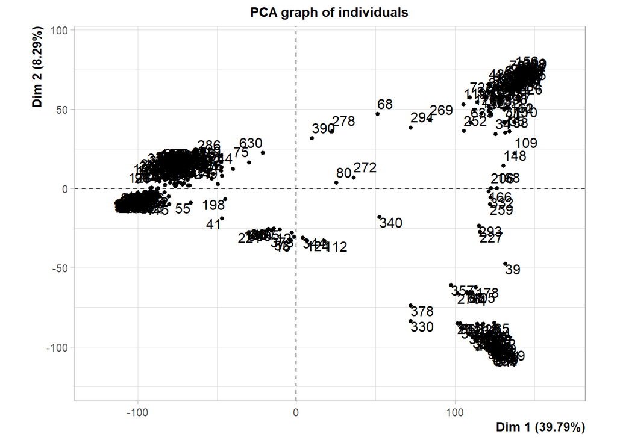

[figure not shown]

```r
res2.pca<-PCA(data,ncp=220, scale.unit = FALSE, graph = TRUE)
```

```r
ind2 <- get_pca_ind(res2.pca)
new_data2<-data.frame(ind2$coord)
data2=new_data2
data2$Target<-data$Target
head(data2)
```

```
##       Dim.1      Dim.2      Dim.3       Dim.4      Dim.5      Dim.6       Dim.7
## 1 -97.84168  -8.533920 -63.840185    3.794138   2.224625  -0.068583   0.9520395
## 3 141.61777  67.692628 -14.404296   -1.316425 -14.072535 -41.215891  15.4846232
## 4 114.95100 -66.981600  10.087619   18.462024  -3.188162 -23.193551 -46.8032127
## 5 -10.66808 -25.742529  10.458750 -126.683006   2.596939  -1.425653  -5.0562322
## 6 107.52691 -65.399245   9.904256   18.582382  -1.736007 -25.567972 -51.9943995
## 7 -55.71144   7.839055  56.986010    3.888786  -3.586553  -2.871043  -4.3726630
##       Dim.8       Dim.9    Dim.10    Dim.11      Dim.12    Dim.13     Dim.14
## 1 -2.159445  -0.9497441 -3.322709 -3.412962 -1.75841166 -4.208018 -2.2962158
## 3  0.444981   4.3968356 -2.129132  1.846151  4.92563779 -4.193891 15.7434727
## 4 20.535401 -56.5985698 -5.944528 19.194853 -1.51926206 -5.879883  4.8281889
## 5 14.497033   3.7847426  4.403453 -3.474549 -0.07449385  1.652381  3.3176099
## 6 20.375885 -61.1163460 -7.070990 16.575035  0.79419729 -7.855327  4.7812361
## 7 -2.715930  -2.3681913  9.596049  7.176588  1.79385696 -9.245690  0.8870196
##       Dim.15     Dim.16      Dim.17     Dim.18       Dim.19     Dim.20
```

[output cut: 216 more lines]

we split our dataset into train and test, with test ratio 20%.

```r
set.seed(4)
index = sample(1:nrow(data2), 0.8*nrow(data2))

train2 = data2[index,] # Create the training data
test2 = data2[-index,] # Create the test data

dim(train2)
```

```
## [1] 322 221
```

```r
dim(test2)
```

```
## [1]  81 221
```

#### Building the linear model

Next, we’ll perform linear regression using PCS (220) since thanks to PCA, n>p so we could apply the regression linear model.

```r
linear=lm(Target~ ., data=train2)
summary(linear)
```

```
##
## Call:
## lm(formula = Target ~ ., data = train2)
##
## Residuals:
##      Min       1Q   Median       3Q      Max
## -1.75381 -0.14297  0.00293  0.18392  1.36254
##
## Coefficients:
##               Estimate Std. Error t value Pr(>|t|)
## (Intercept)  5.6081398  0.1741420  32.204  < 2e-16 ***
## Dim.1       -0.0062803  0.0023893  -2.629 0.009913 **
## Dim.2        0.0056676  0.0049746   1.139 0.257272
## Dim.3       -0.0084667  0.0017639  -4.800  5.5e-06 ***
## Dim.4       -0.0029089  0.0036705  -0.793 0.429922
## Dim.5        0.0082000  0.0051489   1.593 0.114383
## Dim.6        0.0014898  0.0165854   0.090 0.928602
## Dim.7       -0.0272509  0.0190837  -1.428 0.156386
## Dim.8       -0.0039310  0.0069361  -0.567 0.572145
## Dim.9       -0.0107119  0.0145612  -0.736 0.463651
## Dim.10       0.0030601  0.0102802   0.298 0.766570
## Dim.11       0.0333184  0.0125361   2.658 0.009145 **
## Dim.12       0.0339231  0.0170439   1.990 0.049256 *
## Dim.13       0.0016483  0.0100938   0.163 0.870612
## Dim.14      -0.0119203  0.0110746  -1.076 0.284326
## Dim.15      -0.0054808  0.0119684  -0.458 0.647977
## Dim.16       0.0241095  0.0115376   2.090 0.039162 *
## Dim.17       0.0033163  0.0200563   0.165 0.869000
## Dim.18       0.0052592  0.0156267   0.337 0.737155
## Dim.19      -0.0082964  0.0191663  -0.433 0.666036
## Dim.20      -0.0057939  0.0244479  -0.237 0.813144
## Dim.21      -0.0191104  0.0129270  -1.478 0.142432
## Dim.22      -0.0242061  0.0226366  -1.069 0.287469
## Dim.23       0.0253207  0.0232923   1.087 0.279586
## Dim.24       0.0051928  0.0119891   0.433 0.665846
## Dim.25       0.0298143  0.0231131   1.290 0.200020
## Dim.26       0.0029333  0.0166733   0.176 0.860702
## Dim.27       0.0089076  0.0216462   0.412 0.681573
## Dim.28      -0.0239522  0.0271747  -0.881 0.380186
## Dim.29      -0.0101426  0.0197880  -0.513 0.609377
```

[output cut: 182 more lines]

```
## Dim.212     -0.0601356  0.0281033  -2.140 0.034779 *
## Dim.213     -0.0483710  0.0336168  -1.439 0.153273
## Dim.214      0.0164345  0.0232052   0.708 0.480437
## Dim.215     -0.0276026  0.0289193  -0.954 0.342125
## Dim.216      0.0044065  0.0258966   0.170 0.865227
## Dim.217     -0.0356117  0.0246693  -1.444 0.151957
## Dim.218     -0.0599477  0.0300645  -1.994 0.048851 *
## Dim.219      0.0226576  0.0269106   0.842 0.401800
## Dim.220      0.0383173  0.0267292   1.434 0.154792
## ---
## Signif. codes:  0 '***' 0.001 '**' 0.01 '*' 0.05 '.' 0.1 ' ' 1
##
## Residual standard error: 0.7626 on 101 degrees of freedom
## Multiple R-squared:  0.8394, Adjusted R-squared:  0.4895
## F-statistic: 2.399 on 220 and 101 DF,  p-value: 7.981e-07
```

##### Which dimensions are significant

```r
coef=data.frame(summary(linear)$coefficients[ ,4] <=0.05)
colnames(coef)="Significance"
which(coef$Significance==TRUE)
```

```
##  [1]   1   2   4  12  13  17  39  54  65  66  69  70  74  76  88 101 105 108 134
## [20] 135 143 150 158 162 164 167 168 172 189 213 219
```

#### Calculating RMSE for train and the test set

```r
X_test<-as.matrix(subset( test, select = -Target ))
y_test<-test$Target
predicted_lasso=predict(model_lasso,X_test)
predicted_elastic=predict(elastic_mod,X_test)
predicted_stepwise=predict(lm( Target ~ id6004500+id5004697,data=data.frame(train)),data.frame(X_test))
predicted_bestsubset=predict(fit.bestsubset$bestmodel,newdata=data.frame(X_test))
library(Metrics)
rmse_lasso_test=rmse(y_test,predicted_lasso)
rmse_lasso_train=rmse(Y,predict(model_lasso,newx=as.matrix(X)))
# Sum of Squares Total and Error
sst <- sum((Y - mean(Y))^2)
sse <- sum((Y - predict(model_lasso,as.matrix(X)))^2)
rsq_lasso= 1 - sse/sst
# for elastic net
rmse_elastic_train=rmse(Y,predict(elastic_mod,as.matrix(X)))
rmse_elastic_test=rmse(y_test,predicted_elastic)
# Sum of Squares Total and Error
sst <- sum((Y - mean(Y))^2)
sse <- sum((Y - predict(elastic_mod,as.matrix(X)))^2)
# R squared
rsq_elastic <- 1 - (sse / sst)
#for stepwise
rmse_stepwise_test=rmse(y_test,predicted_stepwise)
rmse_stepwise_train=rmse(Y,predict(lm( Target ~ id6004500+id5004697,data=data.frame(train)),data.frame(train)))
rsq_stepwise=summary(lm( Target ~ id6004500+id5004697,data=data.frame(train)))$adj.r.squared
#For Best Subset
rmse_bestsubset_test=rmse(y_test,predicted_bestsubset)
rmse_bestsubset_train=rmse(Y,predict(fit.bestsubset$bestmodel,data.frame(X)))
rsq_bestsubset=summary(fit.bestsubset$bestmodel)$adj.r.squared
#for PCA
rmse_pca_test=rmse(test2$Target,predict(linear,test2))
rmse_pca_train=rmse(train2$Target,predict(linear,train2))
rsq_pca=summary(linear)$adj.r.squared
Models=c("Lasso","Elastic Net","Stepwise","Best Subset","PCA")
RMSE_Train=c(rmse_lasso_train,rmse_elastic_train,rmse_stepwise_train,rmse_bestsubset_train,rmse_pca_train)
RMSE_Test=c(rmse_lasso_test,rmse_elastic_test,rmse_stepwise_test,rmse_bestsubset_test,rmse_pca_test)
R_squared=c(rsq_lasso,rsq_elastic,rsq_stepwise,rsq_bestsubset,rsq_pca)
Models_metrics=data.frame(Models,RMSE_Train,RMSE_Test,R_squared)
library(formattable)
formattable(Models_metrics, list(
RMSE_Train = color_bar("#80ed99"),
RMSE_Test = color_bar("#48cae4"),
R_squared=color_bar("#0066FFFF")))
```

| Models | RMSE_Train | RMSE_Test | R_squared |
| --- | --- | --- | --- |
| Lasso | 0.8136207 | 0.8065875 | 0.4170217 |
| Elastic Net | 0.8193522 | 0.8124142 | 0.4087794 |
| Stepwise | 0.8665166 | 0.8988456 | 0.3346097 |
| Best Subset | 0.3125840 | 1.3934903 | 0.8957680 |
| PCA | 0.4270929 | 9.5364377 | 0.4894519 |